# Getting Started in R

Nicholas Jacob

1/6/2022

```r
knitr::opts_chunk$set(echo = TRUE)
#library(ggplot2)
library(tidyverse)
#testing
```

I just left the above, it is what prints whenever you start a Rmd file. I find it useful to read once in your life. Don’t include it on your projects please!

I am going to try to run through everything I did in python in 01_Python but this time in R. I think you’ll find some things easier and others much harder. I still haven’t decided which language I preffere as they both have their place.

First you should notice that it is a little more challenging to get RStudio going. That is a serious problem for students. I also find the coding a little clunkier than python especially for the basics (for loops, function defining). R is much better at statistics and the tidyverse is a killer library for data munging and vizualization.

## Our Data

```r
df <- read.csv('https://archive.ics.uci.edu/ml/machine-learning-databases/wine/wine.data',header = F)
cols <- c('Class','Alcohol','MalicAcid','Ash','AlcalinityAsh','Magnesium','Phenols','Flavanoids','NonflavanoidPhenols','Proanthocyanins','ColorIntensity','Hue','OD280/OD315','Proline')

colnames(df) <- cols
df %>% head
```

```
##   Class Alcohol MalicAcid  Ash AlcalinityAsh Magnesium Phenols Flavanoids
## 1     1   14.23      1.71 2.43          15.6       127    2.80       3.06
## 2     1   13.20      1.78 2.14          11.2       100    2.65       2.76
## 3     1   13.16      2.36 2.67          18.6       101    2.80       3.24
## 4     1   14.37      1.95 2.50          16.8       113    3.85       3.49
## 5     1   13.24      2.59 2.87          21.0       118    2.80       2.69
## 6     1   14.20      1.76 2.45          15.2       112    3.27       3.39
##   NonflavanoidPhenols Proanthocyanins ColorIntensity  Hue OD280/OD315 Proline
## 1                0.28            2.29           5.64 1.04        3.92    1065
## 2                0.26            1.28           4.38 1.05        3.40    1050
## 3                0.30            2.81           5.68 1.03        3.17    1185
## 4                0.24            2.18           7.80 0.86        3.45    1480
## 5                0.39            1.82           4.32 1.04        2.93     735
## 6                0.34            1.97           6.75 1.05        2.85    1450
```

There is one issue I’ll fix here. R is interpreting ‘Class’ as `int`. I want it to be a factor. Here I am using the tidyverse!

```r
df <- df %>% mutate(Class = as.factor(Class))
```

Okay, on to vizulaizations! Here is the barchart using ggplot. I’ll return to how this works in a bit.

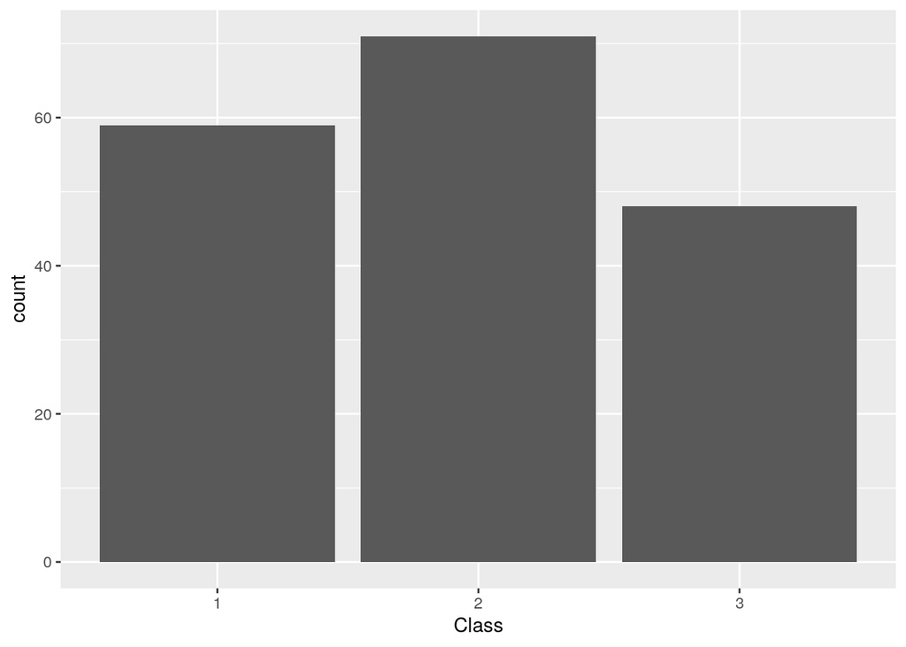

```r
ggplot(data = df, aes(x = Class)) +
  geom_bar()
```

Or in base R, it looks much easier

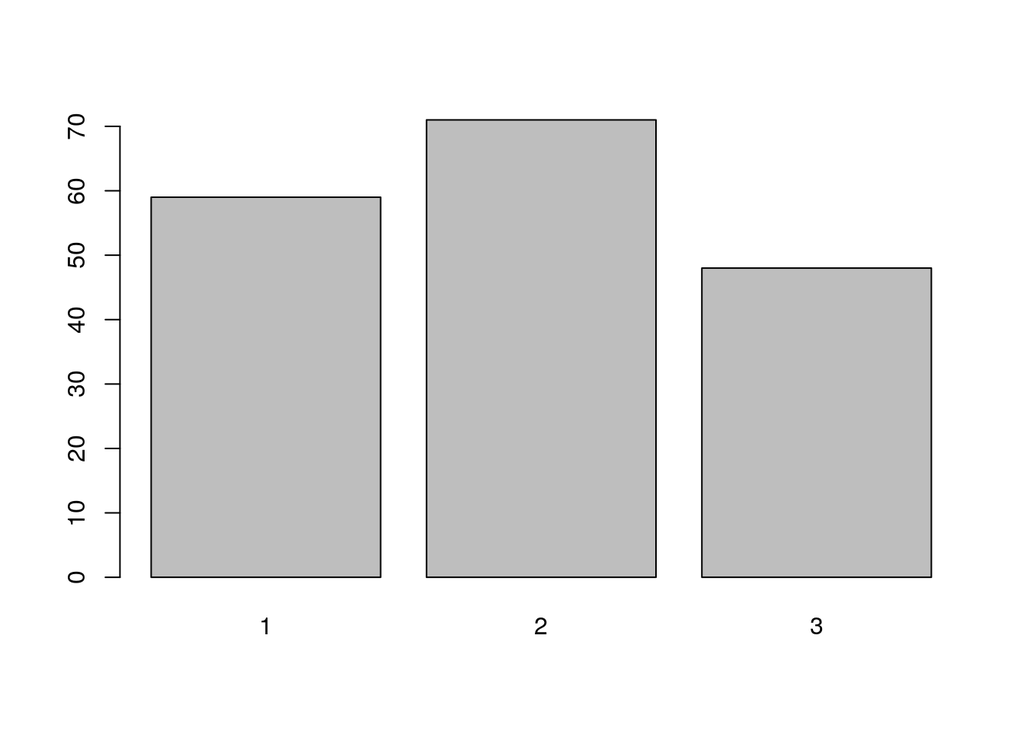

```r
barplot(table(df$Class))
```

BTW, `table` is a sweet command that I totally tried to use in python… It counts how many have the categrories. It will work with multiple columns too.

```r
table(df$Class)
```

```
##
##  1  2  3
## 59 71 48
```

I said no more pies but I was hungry…

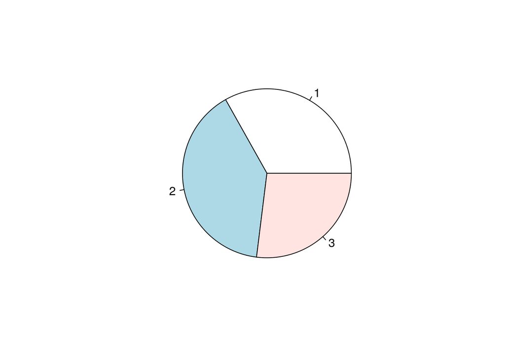

```r
pie(table(df$Class))
```

MMMM, pie!

### Quantitative Data

I’ll move through these quickly, keep in mind base R does not have many options but ggplot does! Here are all the base ones I know off the top of my head.

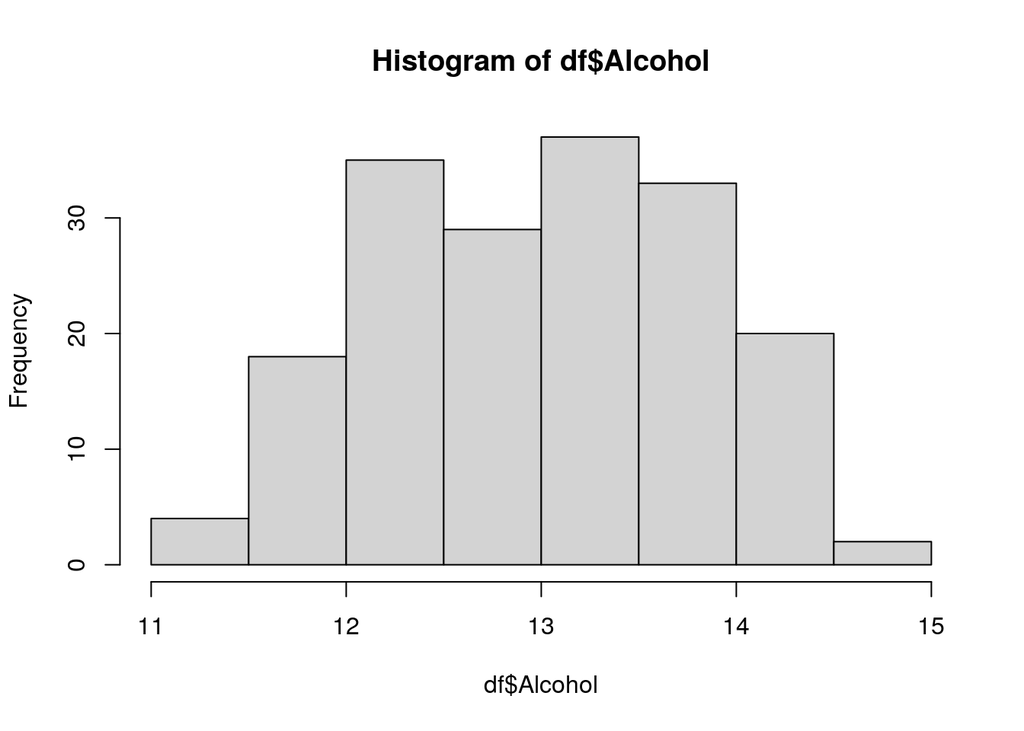

```r
hist(df$Alcohol)
```

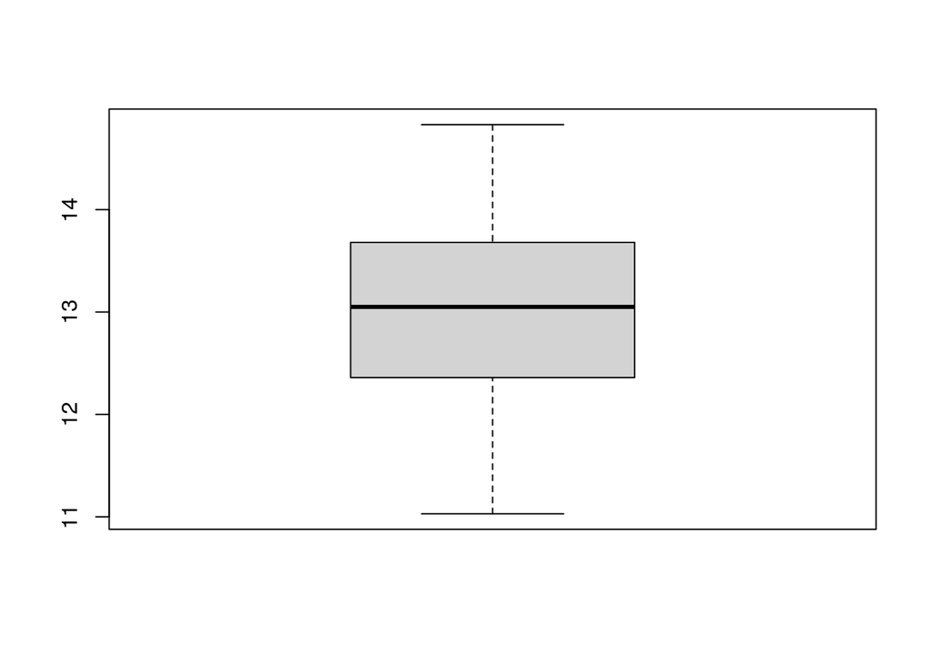

```r
boxplot(df$Alcohol)
```

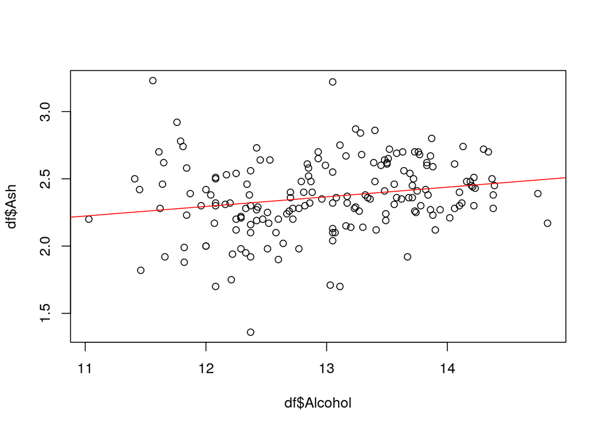

```r
plot(df$Alcohol,df$Ash)
abline(lm(df$Ash~df$Alcohol), col="red") #this is the linear regression line
```

Let’s get to ggplot and talk about how it works. You chain together multiple commands using the `+` this allows you to do a bunch without nesting parentheses! You call ggplot, give it data, then aes will define the aesthetics for the rest of the graph. This alone won’t do anything, then you’ll have to call what kind of graph. After that you can add loads more!

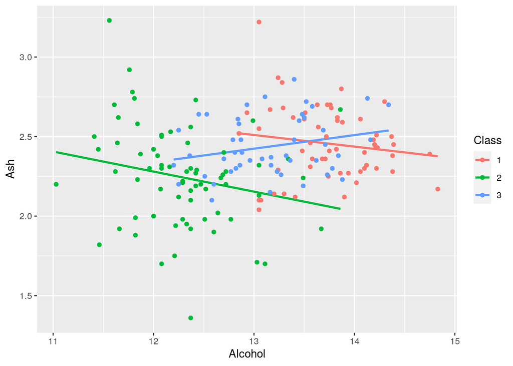

```r
ggplot(df, aes(x = Alcohol, y = Ash, color = Class))+ #setting up the graph
  geom_smooth(se = FALSE, method = lm) + # putting regression lines
  geom_point() # including the points
```

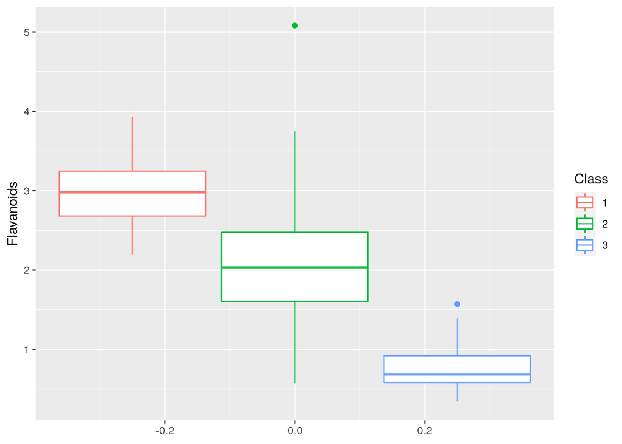

```r
ggplot(df, aes(y = Flavanoids, color = Class)) +
  geom_boxplot()
```

Next, I wanted to recreate the graph I did in python. I used some data transformation here using `pivot_longer` to make the data in a tidier form.

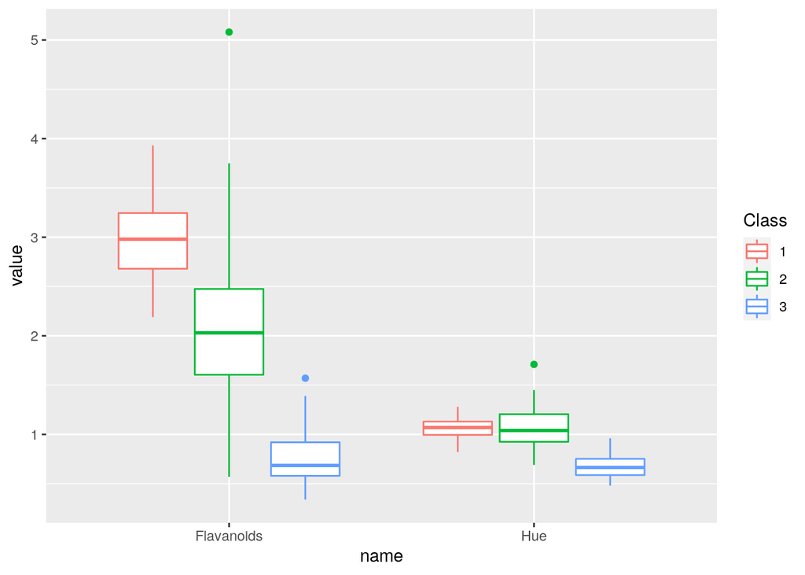

```r
pivot_longer(df[c('Class','Flavanoids','Hue')],cols = c('Flavanoids','Hue')) %>%
  ggplot(aes(x = name, y = value, color = Class)) +
  geom_boxplot()
```

On to the stats. This is the 5 number `summary`

```r
summary(df$Alcohol)
```

```
##    Min. 1st Qu.  Median    Mean 3rd Qu.    Max.
##   11.03   12.36   13.05   13.00   13.68   14.83
```

I should include a mean and standard deviation

```r
mean(df$Alcohol)
```

```
## [1] 13.00062
```

```r
sd(df$Alcohol)
```

```
## [1] 0.8118265
```

I put a bunch of these together. The dplyr package is awesome for combining different things.

```r
df %>%
  group_by(Class) %>%
  summarise(Hue = mean(Hue), Flavanoids = mean(Flavanoids))
```

```
## # A tibble: 3 × 3
##   Class   Hue Flavanoids
##   <fct> <dbl>      <dbl>
## 1 1     1.06       2.98
## 2 2     1.06       2.08
## 3 3     0.683      0.781
```

## Your Turn

1. Create a new Rmd notebook. Title and put your name on your document
2. Load Libraries
3. Gather the iris dataset and load it into your notebook. https://raw.githubusercontent.com/nurfnick/Data_Viz/main/iris.csv
4. Examine the dataset.
5. Create a boxplot of the categorical variable
6. Create visualizations of your favorite variable
7. Histogram
8. Box Plot
9. Violin
10. Compute statistics accompanying the visualizations created
11. Save your notebook and knitted html to GitHub and share the link in the blackboard assignment